# TidalAnalysis

Rob Rossi

12/31/2019

## Read in data

```r
raw_tidal_data <- read.table(file = "RawTidalData.csv", sep=",", header=TRUE)

well_data <-
  read.table(file = "WellData_intfill.csv", sep=",", header=TRUE) %>%
  mutate(
    date_time = as.POSIXct(date_time, tz="EST", "%m/%d/%y %H:%M")
  ) %>%
  filter(date_time >= as.POSIXct("2016-04-25 00:00:00")) #it looks like the water levels are                      equibilrating at the beginning of the record for a few wells so lets trim the beginning of the           dataset to eliminate those records
```

## Process the tidal data

NOAA tidal data is recorded at 6 minute intervals. However, our water level loggers record the water level at 15 minute intervals. This chunk of code takes the NOAA data, averages it over 15 minute intervals, and generates a new dataset that we can use for our time series analyses.

```r
# check to see if there are any unverified data
any(raw_tidal_data$Quality!= "v")
```

```
## [1] FALSE
```

```r
# Cool, there are no unverified data, now lets clean up the data a little, aggregate it by 15 minute intervals, and remove all the extraneous info
tidal_data <-
  raw_tidal_data %>%
  rename(
    date_time = Date.Time,
    water_level = Water.Level
  ) %>%
  mutate(
    date_time = as.POSIXct(date_time, tz="EST", "%m/%d/%y %H:%M"), #changes date_time column from a                   factor to a date
    date_time_15min = cut(date_time, breaks="15 min") #takes each time step and bins it into a 15 minute              interval
  ) %>%
  group_by(date_time_15min) %>%
  summarise(
    water_level_15min = mean(water_level)
  ) %>%
  select(
    date_time_15min,
    water_level_15min
  ) %>%
  mutate(
    date_time_15min = as.POSIXct(date_time_15min, tz="EST", "%Y-%m-%d %H:%M")
  ) %>%
  rename(
    date_time = date_time_15min,
    tide_water_level = water_level_15min
  )
```

## Explore the well water level data

Before we summarize data lets look at the distribution, and eliminate any biased or suspect data

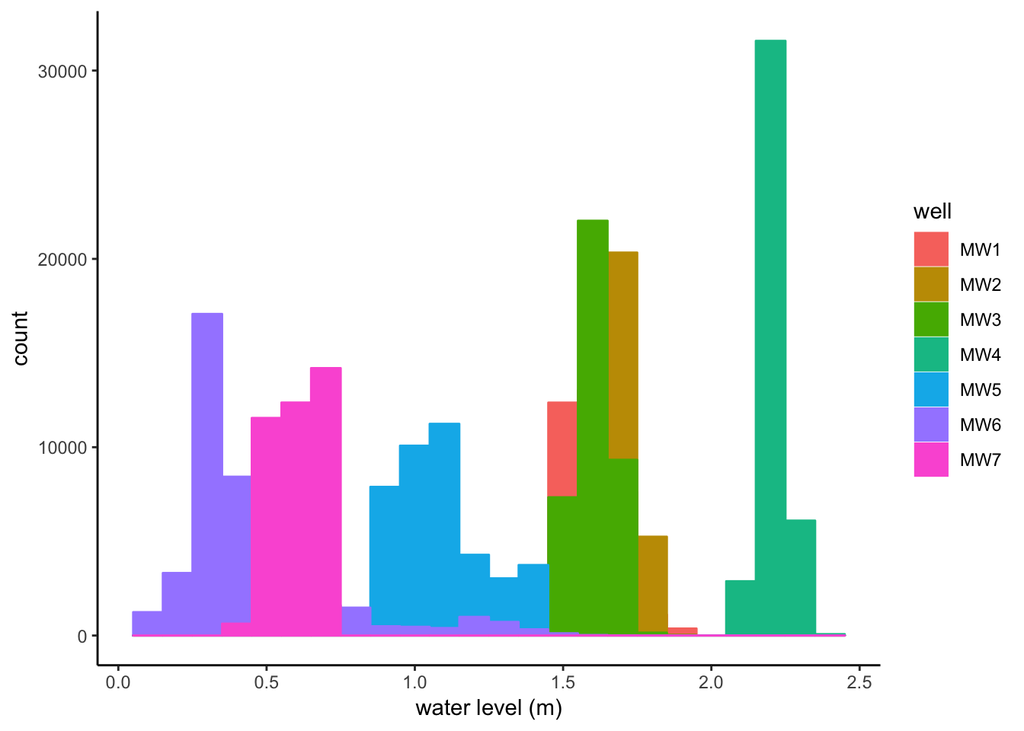

```r
#First let's tidy the well data to simplify plotting and summarizing it.

tidy_well_data <-
  well_data %>%
  gather(
    key = "well",
    value = "water_level",
    na.rm = TRUE,
    MW1,
    MW2,
    MW3,
    MW4,
    MW5,
    MW6,
    MW7)

tidy_well_data %>%
  ggplot(
    aes(x=water_level,
        fill=well,
        color=well)
    ) +
  geom_histogram(
    position="identity",
    binwidth=0.1) +
  labs(y = "count", x = "water level (m)") +
  theme_classic()
```

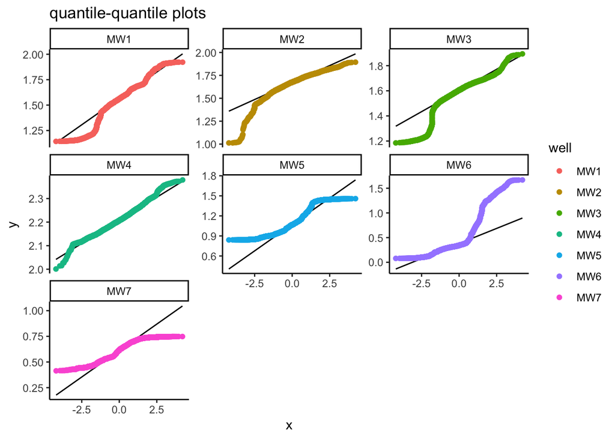

```r
tidy_well_data %>%
  ggplot(
    aes(sample = water_level)) +
  geom_qq_line() +
  geom_qq(
    aes(colour=well)) +
  facet_wrap( ~ well,
              ncol=3,
              scales = "free_y") +
  labs(title = "quantile-quantile plots") +
  theme_classic()
```

From the histograms the wells more or less look like they are normally distributed (except for MW6, and MW5), but the qqplots tell a different story. However since this study doesn’t really focus on differences in the well water levels, summarizing the data with the mean isn’t too terrible.

MW6 does look weird though, both in it’s distribution and the well water level. This warrants further scrutiny. After examining historical maps it looks like MW6 is drilled into 19th century glass works, which means the data from this well isn’t representative of the natural groundwater, and we can eliminate it from further analysis. Now let’s summarize the seasonal and annual water level for each well.

```r
#Make a list of the equinoxes and solstices. Use 2016 since it was a leap year, and to simplfy I'm ignoring that the solostices and equinoxes move.

WS <- as.Date("2016-12-21", format = "%Y-%m-%d") # Winter Solstice
SE <- as.Date("2016-3-20",  format = "%Y-%m-%d") # Spring Equinox
SS <- as.Date("2016-6-20",  format = "%Y-%m-%d") # Summer Solstice
FE <- as.Date("2016-9-22",  format = "%Y-%m-%d") # Fall Equinox

well_data %>%
  mutate(
    date_time = as.POSIXct(date_time, tz="EST", "%m/%d/%y %H:%M"),
    date = as.Date(strftime(date_time, format="2016-%m-%d"))
  ) %>%
  mutate(
    season = case_when(
      date >= SE & date < SS ~ "spring",
      date >= SS & date < FE ~ "summer",
      date >= FE & date < WS ~ "fall",
      TRUE                   ~ "winter")
  ) %>%
  gather(
    key = "well",
    value = "water_level",
    na.rm = TRUE,
    MW1,
    MW2,
    MW3,
    MW4,
    MW5,
    MW7) %>%
  select(
    season,
    well,
    water_level
  ) %>%
  group_by(well, season) %>%
  summarise(
    average = mean(water_level)
  ) %>%
  spread(season, average) %>%
  mutate_if(is.numeric, ~round(., 2))
```

```
## `mutate_if()` ignored the following grouping variables:
## Column `well`
```

```
## # A tibble: 6 x 5
## # Groups:   well [6]
##   well   fall spring summer winter
##   <chr> <dbl>  <dbl>  <dbl>  <dbl>
## 1 MW1   1.61    1.53   1.51   1.57
## 2 MW2   1.64    1.7    1.7    1.61
## 3 MW3   1.59    1.6    1.62   1.55
## 4 MW4   2.19    2.21   2.2    2.22
## 5 MW5   0.97    1.23   1.11   0.95
## 6 MW7   0.570   0.65   0.67   0.52
```

```r
#summarize the annual water levels
tidy_well_data %>%
  filter(well != "MW6") %>%
  group_by(well) %>%
  summarise(
    average = mean(water_level)
  ) %>%
  spread(well, average) %>%
  mutate_if(is.numeric, ~round(., 2))
```

```
## # A tibble: 1 x 6
##     MW1   MW2   MW3   MW4   MW5   MW7
##   <dbl> <dbl> <dbl> <dbl> <dbl> <dbl>
## 1  1.55  1.67  1.59  2.21  1.09  0.61
```

## Combine the tidal and well data

Seeing as all the wells are in the same region, we’d expect trends in the water levels to be the same. Lets plot a snippet of the data and see if there are any wells that do not have tidal signals.

Now that the tidal data is aggregated into 15 minute intervals we can combine it with the water level data in the monitoring wells.

```r
combined_data <-
  well_data %>%
  select(-ends_with("6")) %>% #eliminate MW6
  left_join(tidal_data, by = "date_time")

# a tidy version
tidy_combined_data <-
  tidy_well_data %>%
  select(-ends_with("6")) %>% #eliminate MW6
  left_join(tidal_data, by = "date_time")
```

## Identify which wells have tidal signals

To save analysis work, plot a week’s worth of well water levels to see if there are any wells without a tidal signal.

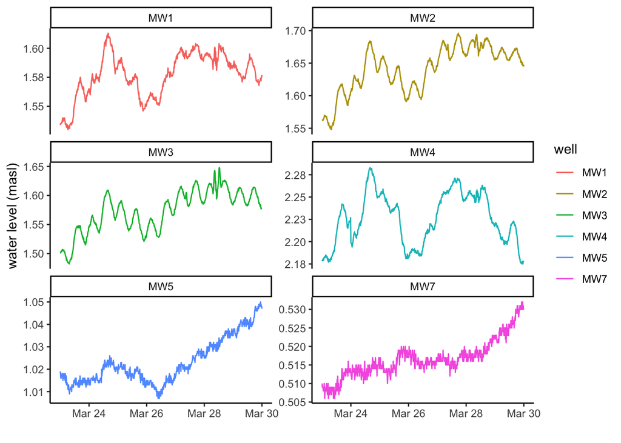

```r
tidy_well_data %>%
  filter(well != "MW6") %>%
  filter(date_time >= as.POSIXct("2017-03-23 00:00:00") &
         date_time <= as.POSIXct("2017-03-30 00:00:00")
         ) %>%
  ggplot(
    aes(x = date_time,
        y = water_level,
        color = well)) +
  geom_line() +
  facet_wrap( ~ well,
              scales = "free_y",
              nrow=3) +
  labs(x = "",
       y = "water level (masl)") + theme_classic()
```

## Cross correlation analysis

Use cross correlation analysis to determine the lag time between tidal oscillations in the wells and the river water.

```r
well_lags <-
  tidy_combined_data %>%

  split(.$well) %>%
  map(~ccf(.$water_level,
           .$tide_water_level,
           plot = F,
           na.action = na.pass)
      ) %>%
  map_dfr(
      ~data.frame(lag = .$lag,
                  acf = .$acf
            ),
      .id = "well") %>%
  filter(lag >= 0 & lag <= 40) %>% #lags less than 0 are correlations where the well water level leads the tidal water level,
  group_by(well) %>%
  summarise(
    lag_time = lag[which.max(acf)]*15 #this converts the lags from timesteps to minutes
  )
```

## Create periodograms

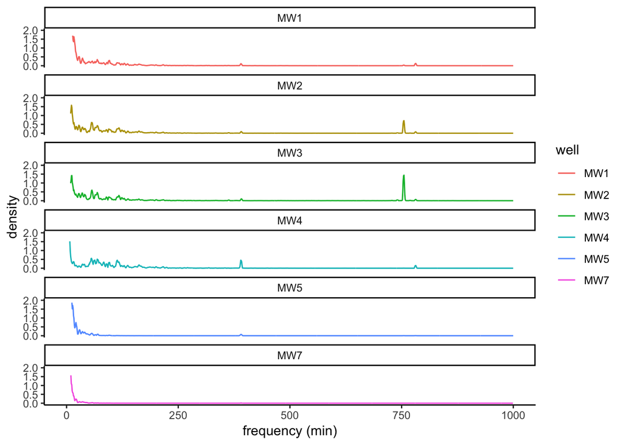

```r
#establish sampling interval (makes x axis be in minutes)
del<-0.02/750
f=del/60

# determine oscillation periods
spectral_data <-
  tidy_combined_data %>%
  filter(well != "MW6") %>%
  split(.$well) %>%
  map(~spectrum(.$water_level,
                log="no",
                span=5,
                plot = F,
                na.action = na.pass)
      ) %>%
  map_dfr(
      ~data.frame(freq = .$freq,
                  spec = .$spec
            ),
      .id = "well") %>%
  group_by(well) %>%
  mutate(frequency_min = freq/del,
         density = 2*spec
  )

#plot the periodograms

spectral_data %>%
  ggplot(
    aes(x = frequency_min,
        y = density,
        color = well)) +
  geom_line() +
  ylim(0,2) + xlim(0,1000) +
  facet_wrap( ~ well,
              nrow=6) +
  theme_classic() + labs(x = "frequency (min)")
```

```r
#eyeballing the plots suggests the major tidal signals are ~ 750, which is roughly 12 hrs. This is the M2 lunar semi-diurnal constituent that is present in tides. There also is a signal at ~ 6 hrs present in most wells, but it's unclear what this signal is. Signals < 250 min are likely noise cause by the data logging interval.


#extract the periods of these major signals

period <-
  spectral_data %>%
  filter(well != "MW5" & well != "MW7") %>% #no tidal signal in these wells
  filter(frequency_min >= 650 & frequency_min <= 800) %>%
  group_by(well) %>%
  summarise(to = frequency_min[which.max(density)])
```

## Hydraulic conductivity calculations

```r
well <- c("MW1", "MW2", "MW3", "MW4")
aquifer_compressibility <- c(10^-7,10^-7,10^-7,10^-8) # Values taken from Freeze and                                                                             Cherry 1979
aquifer_porosity <- c(0.46, 0.43, 0.43, 0.28) # Values taken from Fetter 2001
shoreline_distance <- c(480, 392, 304, 210) # Determined via google earth
slug_k <- c(0.00168598, 0.002004609, 0.001646273, 8.83133E-05) #calculated by field testing

tidal_calcs_data <-
  data.frame(well,
             aquifer_compressibility,
             aquifer_porosity,
             shoreline_distance,
             slug_k) %>%
  left_join(well_lags, by = "well") %>%
  left_join(period, by = "well")
tidal_calcs_data <-
  tidal_calcs_data %>%
  mutate(tidal_effic = aquifer_compressibility/(aquifer_compressibility + aquifer_porosity*4.67e-10 )
            ) %>% #calulate true tidal efficiency
  mutate(spec_stor = (aquifer_porosity*4.67e-10*9.8e3)/(1-tidal_effic)
         ) %>% #calculate specific storage
  mutate(tidal_k = (spec_stor*to*shoreline_distance^2)/(4*pi*lag_time^2)*(1/60)
         ) #calculate k using tidal diffusivity method
```

Now test if the k determined by field tests (slug_k) and the k calculated by the Jacob–Ferris tidal method is different

```r
  t.test(x = tidal_calcs_data$tidal_k,
         y= tidal_calcs_data$slug_k,
         paired = FALSE,
         var.equal = FALSE) #use welch's t-test
```

```
##
##  Welch Two Sample t-test
##
## data:  tidal_calcs_data$tidal_k and tidal_calcs_data$slug_k
## t = 0.2, df = 6, p-value = 0.9
## alternative hypothesis: true difference in means is not equal to 0
## 95 percent confidence interval:
##  -0.00143  0.00161
## sample estimates:
## mean of x mean of y
##   0.00145   0.00136
```

there is no statistically significant difference between the k’s detrmined via the two methods.

## Fast Fourier transforms

Use fft to determine the amplitude and phase of tidal oscillations in each well

```r
#Fast Fourier Transform to get amplitude and phase for each well

time <- 824/1.9322

any(is.na(tidy_well_data)) #there are no NAs in the data, we can proceed with the fft
```

```
## [1] FALSE
```

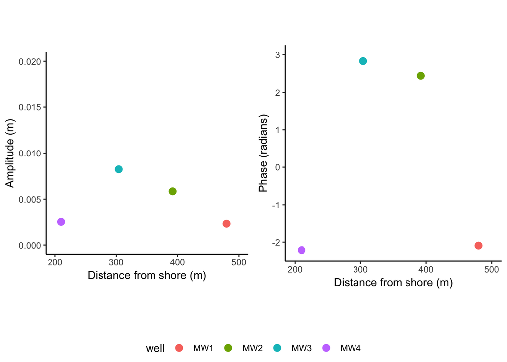

```r
fft_data <-
  tidy_well_data %>%
  filter(well != "MW5" &
         well != "MW6" &
         well != "MW7") %>% #no tidal signal in these wells, so no reason to fft
  split(.$well) %>%
  map(~fft(.$water_level)
      ) %>%
  map_dfr(
      ~data.frame(mag = Mod(.),
                  phase = Arg(.)
            ),
      .id = "well") %>%
  group_by(well) %>%
  mutate(amp = mag/length(mag)) %>%
  group_by(well) %>%
  summarise(max_amp = max(amp[770:870]),
            max_phase = phase[amp == max_amp])

#Plot phase and amplitude against distance from the shore

amp_plot <-
  tidal_calcs_data %>%
  select(well,
         shoreline_distance) %>%
  left_join(fft_data, by = "well") %>%
  ggplot(
    aes(x = shoreline_distance,
        y = max_amp,
        color = well)) +
  geom_point(size = 3) +
  ylim(0,0.02) + xlim(200,500) +
  labs(x = "Distance from shore (m)",
       y = "Amplitude (m)") +
  theme_classic() + theme(aspect.ratio=1)

phase_plot <-
  tidal_calcs_data %>%
  select(well,
         shoreline_distance) %>%
  left_join(fft_data, by = "well") %>%
  ggplot(
    aes(x = shoreline_distance,
        y = max_phase,
        color = well)) +
  geom_point(size = 3) +
  ylim(-2.25,3.0) + xlim(200,500) +
  labs(x = "Distance from shore (m)",
       y = "Phase (radians)") +
  theme_classic() + theme(aspect.ratio=1)

ggarrange(amp_plot, phase_plot,
          widths = c(2,2), heights = c(2,2),
          ncol = 2, common.legend = TRUE, legend="bottom")
```